# Supervised Learning - Foundations Project: ReCell

## Problem Statement

### Business Context

Buying and selling used phones and tablets used to be something that happened on a handful of online marketplace sites. But the used and refurbished device market has grown considerably over the past decade, and a new IDC (International Data Corporation) forecast predicts that the used phone market would be worth \$52.7bn by 2023 with a compound annual growth rate (CAGR) of 13.6% from 2018 to 2023. This growth can be attributed to an uptick in demand for used phones and tablets that offer considerable savings compared with new models.

Refurbished and used devices continue to provide cost-effective alternatives to both consumers and businesses that are looking to save money when purchasing one. There are plenty of other benefits associated with the used device market. Used and refurbished devices can be sold with warranties and can also be insured with proof of purchase. Third-party vendors/platforms, such as Verizon, Amazon, etc., provide attractive offers to customers for refurbished devices. Maximizing the longevity of devices through second-hand trade also reduces their environmental impact and helps in recycling and reducing waste. The impact of the COVID-19 outbreak may further boost this segment as consumers cut back on discretionary spending and buy phones and tablets only for immediate needs.

### Objective

The rising potential of this comparatively under-the-radar market fuels the need for an ML-based solution to develop a dynamic pricing strategy for used and refurbished devices. ReCell, a startup aiming to tap the potential in this market, has hired you as a data scientist. They want you to analyze the data provided and build a linear regression model to predict the price of a used phone/tablet and identify factors that significantly influence it.

### Data Description

The data contains the different attributes of used/refurbished phones and tablets. The data was collected in the year 2021. The detailed data dictionary is given below.

- brand_name: Name of manufacturing brand
- os: OS on which the device runs
- screen_size: Size of the screen in cm
- 4g: Whether 4G is available or not
- 5g: Whether 5G is available or not
- main_camera_mp: Resolution of the rear camera in megapixels
- selfie_camera_mp: Resolution of the front camera in megapixels
- int_memory: Amount of internal memory (ROM) in GB
- ram: Amount of RAM in GB
- battery: Energy capacity of the device battery in mAh
- weight: Weight of the device in grams
- release_year: Year when the device model was released
- days_used: Number of days the used/refurbished device has been used
- normalized_new_price: Normalized price of a new device of the same model in euros
- normalized_used_price: Normalized price of the used/refurbished device in euros

## Importing necessary libraries

```python
import pandas as pd
import numpy as np

# for visualizing data
import matplotlib.pyplot as plt
import seaborn as sns

# For randomized data splitting
from sklearn.model_selection import train_test_split

# To build linear regression_model
import statsmodels.api as sm

# To check model performance
from sklearn.metrics import mean_absolute_error, mean_squared_error
```

## Loading the dataset

```python
from google.colab import files
import io

try:
    uploaded
except NameError:
    uploaded = files.upload()

data = pd.read_csv(io.BytesIO(uploaded['used_device_data.csv']))
```

Upload widget is only available when the cell has been executed in the current browser session. Please rerun this cell to enable.

```
Saving used_device_data.csv to used_device_data.csv
```

## Data Overview

- Observations
- Sanity checks

```python
# look at first 5 rows
data.head()
```

|  | brand_name | os | screen_size | 4g | 5g | main_camera_mp | selfie_camera_mp | int_memory | ram | battery | weight | release_year | days_used | normalized_used_price | normalized_new_price |
| --- | --- | --- | --- | --- | --- | --- | --- | --- | --- | --- | --- | --- | --- | --- | --- |
| 0 | Honor | Android | 14.50 | yes | no | 13.0 | 5.0 | 64.0 | 3.0 | 3020.0 | 146.0 | 2020 | 127 | 4.307572 | 4.715100 |
| 1 | Honor | Android | 17.30 | yes | yes | 13.0 | 16.0 | 128.0 | 8.0 | 4300.0 | 213.0 | 2020 | 325 | 5.162097 | 5.519018 |
| 2 | Honor | Android | 16.69 | yes | yes | 13.0 | 8.0 | 128.0 | 8.0 | 4200.0 | 213.0 | 2020 | 162 | 5.111084 | 5.884631 |
| 3 | Honor | Android | 25.50 | yes | yes | 13.0 | 8.0 | 64.0 | 6.0 | 7250.0 | 480.0 | 2020 | 345 | 5.135387 | 5.630961 |
| 4 | Honor | Android | 15.32 | yes | no | 13.0 | 8.0 | 64.0 | 3.0 | 5000.0 | 185.0 | 2020 | 293 | 4.389995 | 4.947837 |

```python
# look at last 5 rows
data.tail()
```

|  | brand_name | os | screen_size | 4g | 5g | main_camera_mp | selfie_camera_mp | int_memory | ram | battery | weight | release_year | days_used | normalized_used_price | normalized_new_price |
| --- | --- | --- | --- | --- | --- | --- | --- | --- | --- | --- | --- | --- | --- | --- | --- |
| 3449 | Asus | Android | 15.34 | yes | no | NaN | 8.0 | 64.0 | 6.0 | 5000.0 | 190.0 | 2019 | 232 | 4.492337 | 6.483872 |
| 3450 | Asus | Android | 15.24 | yes | no | 13.0 | 8.0 | 128.0 | 8.0 | 4000.0 | 200.0 | 2018 | 541 | 5.037732 | 6.251538 |
| 3451 | Alcatel | Android | 15.80 | yes | no | 13.0 | 5.0 | 32.0 | 3.0 | 4000.0 | 165.0 | 2020 | 201 | 4.357350 | 4.528829 |
| 3452 | Alcatel | Android | 15.80 | yes | no | 13.0 | 5.0 | 32.0 | 2.0 | 4000.0 | 160.0 | 2020 | 149 | 4.349762 | 4.624188 |
| 3453 | Alcatel | Android | 12.83 | yes | no | 13.0 | 5.0 | 16.0 | 2.0 | 4000.0 | 168.0 | 2020 | 176 | 4.132122 | 4.279994 |

```python
# check the number of rows & columns
data.shape
```

```
(3454, 15)
```

Observation: There are 3454 rows and 15 columns in the dataset.

```python
# check data types and for nulls
data.info()
```

```
<class 'pandas.core.frame.DataFrame'>
RangeIndex: 3454 entries, 0 to 3453
Data columns (total 15 columns):
 #   Column                 Non-Null Count  Dtype
---  ------                 --------------  -----
 0   brand_name             3454 non-null   object
 1   os                     3454 non-null   object
 2   screen_size            3454 non-null   float64
 3   4g                     3454 non-null   object
 4   5g                     3454 non-null   object
 5   main_camera_mp         3275 non-null   float64
 6   selfie_camera_mp       3452 non-null   float64
 7   int_memory             3450 non-null   float64
 8   ram                    3450 non-null   float64
 9   battery                3448 non-null   float64
 10  weight                 3447 non-null   float64
 11  release_year           3454 non-null   int64
 12  days_used              3454 non-null   int64
 13  normalized_used_price  3454 non-null   float64
 14  normalized_new_price   3454 non-null   float64
dtypes: float64(9), int64(2), object(4)
memory usage: 404.9+ KB
```

```python
# another check for null values to confirm
data.isnull().sum()
```

```
brand_name                 0
os                         0
screen_size                0
4g                         0
5g                         0
main_camera_mp           179
selfie_camera_mp           2
int_memory                 4
ram                        4
battery                    6
weight                     7
release_year               0
days_used                  0
normalized_used_price      0
normalized_new_price       0
dtype: int64
```

It appears that there may be null values in 6 columns: main_camera_mp, selfie_camera_mp, int_memory, ram, battery, & weight. We will correct this in the data preprocessing steps.

```python
# print the statistical summary for each variable
data.describe(include='all').T
```

|  | count | unique | top | freq | mean | std | min | 25% | 50% | 75% | max |
| --- | --- | --- | --- | --- | --- | --- | --- | --- | --- | --- | --- |
| brand_name | 3454 | 34 | Others | 502 | NaN | NaN | NaN | NaN | NaN | NaN | NaN |
| os | 3454 | 4 | Android | 3214 | NaN | NaN | NaN | NaN | NaN | NaN | NaN |
| screen_size | 3454.0 | NaN | NaN | NaN | 13.713115 | 3.80528 | 5.08 | 12.7 | 12.83 | 15.34 | 30.71 |
| 4g | 3454 | 2 | yes | 2335 | NaN | NaN | NaN | NaN | NaN | NaN | NaN |
| 5g | 3454 | 2 | no | 3302 | NaN | NaN | NaN | NaN | NaN | NaN | NaN |
| main_camera_mp | 3275.0 | NaN | NaN | NaN | 9.460208 | 4.815461 | 0.08 | 5.0 | 8.0 | 13.0 | 48.0 |
| selfie_camera_mp | 3452.0 | NaN | NaN | NaN | 6.554229 | 6.970372 | 0.0 | 2.0 | 5.0 | 8.0 | 32.0 |
| int_memory | 3450.0 | NaN | NaN | NaN | 54.573099 | 84.972371 | 0.01 | 16.0 | 32.0 | 64.0 | 1024.0 |
| ram | 3450.0 | NaN | NaN | NaN | 4.036122 | 1.365105 | 0.02 | 4.0 | 4.0 | 4.0 | 12.0 |
| battery | 3448.0 | NaN | NaN | NaN | 3133.402697 | 1299.682844 | 500.0 | 2100.0 | 3000.0 | 4000.0 | 9720.0 |
| weight | 3447.0 | NaN | NaN | NaN | 182.751871 | 88.413228 | 69.0 | 142.0 | 160.0 | 185.0 | 855.0 |
| release_year | 3454.0 | NaN | NaN | NaN | 2015.965258 | 2.298455 | 2013.0 | 2014.0 | 2015.5 | 2018.0 | 2020.0 |
| days_used | 3454.0 | NaN | NaN | NaN | 674.869716 | 248.580166 | 91.0 | 533.5 | 690.5 | 868.75 | 1094.0 |
| normalized_used_price | 3454.0 | NaN | NaN | NaN | 4.364712 | 0.588914 | 1.536867 | 4.033931 | 4.405133 | 4.7557 | 6.619433 |
| normalized_new_price | 3454.0 | NaN | NaN | NaN | 5.233107 | 0.683637 | 2.901422 | 4.790342 | 5.245892 | 5.673718 | 7.847841 |

Observations:

- Android is the most frequent operating system
- Most phones seem to be 4g but not 5g compatible
- The average weight of the phones is 182.7 grams
- The phones were released between 2013 & 2020
- The phones were used for an average of ~675 days or less than 2 years

```python
# check the unique values for each of the columns
data['brand_name'].unique()
```

```
array(['Honor', 'Others', 'HTC', 'Huawei', 'Infinix', 'Lava', 'Lenovo',
       'LG', 'Meizu', 'Micromax', 'Motorola', 'Nokia', 'OnePlus', 'Oppo',
       'Realme', 'Samsung', 'Vivo', 'Xiaomi', 'ZTE', 'Apple', 'Asus',
       'Coolpad', 'Acer', 'Alcatel', 'BlackBerry', 'Celkon', 'Gionee',
       'Google', 'Karbonn', 'Microsoft', 'Panasonic', 'Sony', 'Spice',
       'XOLO'], dtype=object)
```

```python
data['os'].unique()
```

```
array(['Android', 'Others', 'iOS', 'Windows'], dtype=object)
```

```python
data['screen_size'].unique()
```

```
array([14.5 , 17.3 , 16.69, 25.5 , 15.32, 16.23, 13.84, 15.77, 15.47,
       15.9 , 16.74, 25.43, 20.32, 15.29, 12.88, 15.24, 15.37, 16.71,
       25.6 , 15.34, 16.59, 16.81, 20.42, 10.16, 17.78, 17.32, 15.39,
       12.7 , 15.44,  5.28, 15.27, 15.8 , 15.72, 12.83,  7.62,  7.75,
       10.03, 15.42, 16.56,  5.18, 16.64, 16.94, 16.33, 10.29, 16.43,
       12.93, 16.36, 16.66, 16.21, 17.5 , 16.13, 16.28, 14.4 , 15.21,
       20.12, 16.89, 16.48, 16.31, 25.53, 12.73, 20.55, 30.71, 27.94,
       25.45, 18.01, 14.35, 16.15, 23.04, 10.34, 10.24, 12.78, 12.75,
       23.01, 11.81, 11.84, 10.36, 11.76, 12.9 , 17.4 , 14.55, 12.8 ,
        7.65, 10.21,  5.08,  5.13,  5.23, 20.35, 12.57, 18.08, 17.65,
       14.83, 15.06, 13.08, 15.14, 30.56, 19.96, 19.94, 25.4 , 11.89,
       15.62, 17.83,  7.85,  7.67, 16.08, 17.73, 12.52, 20.4 ,  7.82,
       15.11, 13.87, 13.61,  5.16, 10.08, 25.55, 15.7 , 14.88, 15.95,
       15.82,  7.7 , 14.53, 17.86, 12.85, 13.34, 11.48,  7.98, 30.53,
        7.8 , 12.12,  8.31,  6.68, 10.31, 11.56, 14.86, 14.94, 13.79,
       13.56, 15.16, 12.67, 10.19, 16.84, 17.81, 14.81])
```

```python
data['4g'].unique()
```

```
array(['yes', 'no'], dtype=object)
```

```python
data['5g'].unique()
```

```
array(['no', 'yes'], dtype=object)
```

```python
data['main_camera_mp'].unique()
```

```
array([13.  ,  8.  ,  5.  , 10.5 ,  3.15,   nan,  2.  , 16.  ,  0.3 ,
       12.  , 14.5 , 48.  ,  3.  , 21.  ,  1.3 , 13.1 , 24.  ,  0.08,
       20.7 , 23.  ,  1.  , 18.  , 12.2 , 12.3 , 20.  , 20.2 ,  4.  ,
       12.5 , 10.  ,  6.5 ,  6.7 , 41.  , 20.1 , 12.6 , 16.3 , 22.6 ,
       19.  , 21.5 , 21.2 ,  8.1 ,  1.2 , 22.5 ])
```

```python
data['selfie_camera_mp'].unique()
```

```
array([ 5.  , 16.  ,  8.  , 32.  ,  2.  ,  0.3 , 13.  , 14.5 , 24.  ,
       10.  ,  1.3 , 20.  , 25.  ,  0.  , 12.  ,  7.  ,  1.2 ,  3.  ,
        2.1 ,  1.  ,  4.  ,  1.1 ,   nan, 10.5 ,  1.6 ,  1.8 ,  3.5 ,
        0.9 ,  1.25, 18.  ,  1.9 ,  9.  ,  3.7 , 16.3 ,  5.1 ,  2.2 ,
       14.  ,  0.65])
```

```python
data['int_memory'].unique()
```

```
array([6.400e+01, 1.280e+02, 3.200e+01, 1.600e+01, 2.560e+02, 5.120e+02,
       8.000e+00, 4.000e+00, 5.000e-01, 2.000e-01, 1.000e-01, 6.000e-02,
             nan, 1.024e+03, 2.400e+01, 1.000e-02])
```

```python
data['ram'].unique()
```

```
array([ 3.  ,  8.  ,  6.  ,  4.  ,  2.  ,  1.  , 12.  ,  0.5 ,  0.25,
        0.03,   nan,  0.02,  1.5 ])
```

```python
data['battery'].unique()
```

```
array([3020. , 4300. , 4200. , 7250. , 5000. , 4000. , 3400. , 4100. ,
       3750. , 5100. , 5680. , 3850. , 3075. , 3300. , 3930. , 4500. ,
       7500. , 6100. , 3500. , 1700. , 6000. , 3200. , 3000. , 7000. ,
       3590. , 4050. , 8400. , 1470. , 3450. , 8200. , 1540. , 3600. ,
       1500. , 2000. , 1020. , 1200. , 4085. , 4230. , 4025. , 4035. ,
       4020. , 4065. , 3130. , 3090. , 3820. , 2700. , 4315. , 4350. ,
       4030. , 3700. , 3260. , 3940. , 1900. , 2920. , 4520. , 4800. ,
       5020. , 2600. , 7040. , 7600. , 2800. , 9720. , 5770.5, 8827. ,
       7812. , 5124. , 3230. , 2200. , 1760. , 3100. , 3240. , 2840. ,
       1800. , 2460. , 4080. , 4420. , 2870. , 2420. , 5910. , 4550. ,
       2300. , 1300. , 2100. , 2500. , 4600. , 1630. , 2955. , 2400. ,
       7300. , 4960. , 2640. , 2710. , 2580. , 2850. , 2050. , 2150. ,
       2960. , 2610. , 2910. , 2820. , 1400. , 1000. , 4060. ,  750. ,
        850. , 3050. , 3150. , 2350. , 3140. , 1850. , 1350. , 1920. ,
       1420. , 1750. , 8000. , 4400. , 1280. , 3830. , 3210. , 2980. ,
       3969. , 3174. , 2658. , 2942. , 5493. , 2716. , 2691. , 1821. ,
       2256. , 8134. , 2900. , 1960. , 7306. , 1624. , 2750. , 1715. ,
       3937. , 7340. , 6470. , 2915. , 1810. , 8600. , 1560. , 1510. ,
       6600. , 2950. , 4130. , 4680. , 2650. , 7800. , 3480. , 5900. ,
       2070. , 3010. , 1600. , 4890. , 2040. , 3030. , 3950. , 2060. ,
       2110. , 2865. , 3910. , 1820. , 1170. , 5070. , 4270. , 1840. ,
       2520. , 3410. , 2515. , 2880. , 1450. , 2180. , 4180. , 3180. ,
       6180. , 2020. , 2250. ,  820. ,  620. , 3080. , 3120. , 3620. ,
       2470. , 7280. , 3800. , 2630. , 1150. , 4070. , 4010. , 2670. ,
       6020. , 3065. , 2530. , 1950. , 3430. , 3520. , 2770. , 9240. ,
       3340. , 1730. , 2550. , 4150. , 8380. , 2965. , 2730. , 6700. ,
       1650. , 1230. , 1860. , 3650. , 2280. , 6660. , 4360. , 2680. ,
       1975. , 4450. , 1625. , 2620. , 2560. , 5180. , 3350. , 3760. ,
       4850. , 4250. , 9300. , 4290. , 4900. , 6200. , 2410. , 9600. ,
       6400. , 6340. , 9000. , 3550. , 2660. , 1940. , 2125. , 7400. ,
       2540. ,  950. , 2440. , 3570. , 3070. , 3360. , 3235. , 3060. ,
       2760. , 3095. ,    nan, 2260. , 2450. , 1905. , 3510. , 2390. ,
       3900. , 3220. , 1980. , 2130. , 1785. , 3320. , 2970. , 2990. ,
       1100. , 1830. , 5300. , 1430. , 1010. , 1110. , 5200. , 5400. ,
       2525. , 3765. , 3730. , 4120. , 2320. , 2140. , 3610. ,  800. ,
       2210. , 1030. , 4700. , 4380. , 6150. , 5870. , 7900. , 2430. ,
       6800. , 9500. , 8220. , 2330. , 2030. , 3330. , 3580. , 3540. ,
       2930. , 2370. , 3315. , 3425. , 3250. , 3225. , 4015. , 3160. ,
       5830. , 1780. , 1880. , 5500. , 8620. , 2860. , 6190. , 2230. ,
        500. , 3630. , 2705. , 2480. , 4260. , 4045. , 5260. , 4160. ,
       4720. , 4780. , 4235. , 3046. , 3110. ])
```

```python
data['weight'].unique()
```

```
array([146.  , 213.  , 480.  , 185.  , 176.  , 144.  , 164.  , 165.  ,
       150.  , 206.  , 171.5 , 172.  , 173.  , 453.6 , 170.  , 160.  ,
       180.  , 192.  , 182.  , 163.  , 310.  , 189.  , 450.  , 226.  ,
       460.  , 183.  , 178.  , 198.  , 196.  , 163.5 , 498.  , 340.  ,
       320.  , 171.  , 196.8 , 136.1 , 350.  , 209.  , 147.6 , 520.  ,
       580.  , 305.  , 236.  , 159.  , 655.  , 196.5 , 219.  , 127.  ,
       218.  , 148.  , 152.  , 186.  , 194.  , 175.  , 179.  , 140.45,
       199.  , 184.  , 166.  , 146.5 ,  89.  ,  85.  , 210.  , 203.  ,
       200.  ,  90.5 ,  91.3 , 220.  ,  88.2 ,  86.5 , 168.  , 181.  ,
       169.5 , 190.  , 215.  , 135.  , 191.  , 195.  , 313.  , 141.  ,
       206.5 , 153.  , 234.  , 204.1 , 181.5 , 190.2 , 197.  , 198.1 ,
       219.5 , 198.5 , 193.  , 186.7 , 191.5 , 190.5 , 218.5 , 217.3 ,
       217.  , 189.5 , 130.  , 145.  , 208.  , 205.  , 188.  , 241.  ,
       173.8 , 157.  , 154.  , 187.  , 467.  , 168.1 , 420.  , 256.  ,
       653.  , 169.  , 338.  , 184.7 , 330.  , 191.6 , 242.  , 505.2 ,
       138.  , 176.6 , 355.  , 374.  , 641.  , 471.  , 483.  , 468.  ,
       299.  , 158.  , 136.  , 508.  ,  90.  , 295.1 , 325.  , 279.  ,
       285.  , 390.  , 400.  , 153.2 , 544.3 , 260.  , 126.  , 147.5 ,
       125.  , 353.8 , 142.  , 540.  , 110.  , 118.  , 120.  , 119.  ,
       116.  , 155.  , 360.  , 298.  , 159.5 , 134.  , 122.  , 323.  ,
       315.  , 380.  , 229.  , 560.  , 410.  , 140.  , 339.9 , 151.  ,
       415.  , 245.  , 147.  , 156.  , 163.9 , 159.95, 149.  , 174.  ,
       144.9 , 142.95, 335.  ,  98.  , 114.  , 101.  ,  93.  , 149.1 ,
       121.1 , 327.  , 100.  ,  95.  ,  77.9 , 162.  , 103.  , 128.  ,
       136.5 , 117.4 , 177.6 ,  96.  , 108.  , 119.5 , 115.  , 109.  ,
       139.  , 143.6 , 167.5 , 209.8 , 137.  , 155.3 , 143.  , 118.5 ,
       212.  , 156.5 , 135.5 , 204.4 , 119.8 , 149.7 , 146.4 , 139.2 ,
        97.  , 156.2 ,  98.9 , 118.7 , 129.  , 143.1 , 150.5 , 143.5 ,
       402.  , 645.4 , 282.  , 472.4 , 289.  , 357.  ,  80.  , 131.9 ,
       153.7 , 147.7 , 129.4 , 110.6 , 137.7 , 124.9 , 176.9 , 113.6 ,
       122.7 , 140.7 , 500.  , 369.  , 295.  , 337.  , 290.  , 303.  ,
       345.  , 456.  , 300.5 , 631.  , 177.  , 469.  , 202.  , 677.  ,
       437.  , 113.  , 713.  , 331.  , 112.  , 132.  , 214.  , 510.  ,
       223.  , 232.  , 490.  , 270.  , 430.  , 158.4 , 233.  , 133.5 ,
       170.1 , 272.  , 155.1 , 265.  , 280.  , 525.  , 148.8 , 269.  ,
       328.  , 595.  , 550.  , 105.  , 522.  , 585.  , 302.  , 370.  ,
       167.  , 137.5 , 142.6 , 207.  , 106.  , 404.  , 133.  , 124.  ,
        69.  , 243.  , 470.  , 250.  , 161.  , 115.3 , 102.  ,  78.2 ,
       173.4 , 138.5 , 597.  , 292.  , 142.5 ,  92.  , 121.  , 154.5 ,
       130.5 , 135.6 , 238.  , 168.2 , 207.7 , 147.2 , 167.6 , 136.6 ,
```

[output cut: 15 more lines]

```
       111.4 , 110.2 , 101.3 , 101.1 ,  89.6 ,  98.2 ,  97.3 , 103.7 ,
       356.  , 132.5 , 140.75, 154.85, 146.7 , 612.  , 621.  , 406.  ,
       680.  , 660.  , 263.  , 358.  , 201.  , 364.  , 429.  , 184.8 ,
       283.  , 322.  , 110.3 , 393.  , 136.9 , 130.3 , 123.8 , 107.6 ,
       294.  , 465.  , 135.8 , 276.  , 487.  ,  91.  , 162.5 , 753.  ,
       750.  , 740.  , 732.  , 730.2 , 477.  , 134.2 , 121.9 , 118.9 ,
       118.2 , 130.4 ,  99.5 , 118.8 , 314.  , 119.1 , 128.5 , 143.9 ,
       100.5 , 130.1 ,  89.2 , 120.6 , 139.1 , 148.5 , 167.4 , 221.  ,
       164.4 , 137.4 , 389.  , 143.8 , 170.6 , 439.  , 426.  , 171.7 ,
       123.3 , 196.3 , 354.4 , 630.5 , 671.3 , 598.7 , 190.25, 149.3 ,
       162.8 , 183.2 , 157.8 , 158.6 , 183.5 , 172.5 , 140.5 , 167.8 ,
       167.9 , 342.5 , 485.  , 131.5 ,    nan, 148.85, 151.3 , 171.1 ,
       158.8 , 174.9 , 149.5 , 194.8 , 172.9 , 139.3 , 189.9 , 135.55,
       117.9 , 127.6 , 153.4 , 152.9 , 189.4 , 183.6 , 181.4 , 214.5 ,
       201.8 , 253.  , 222.  , 240.  ])
```

```python
data['release_year'].unique()
```

```
array([2020, 2019, 2013, 2014, 2016, 2018, 2015, 2017])
```

```python
data['days_used'].unique()
```

```
array([ 127,  325,  162,  345,  293,  223,  234,  219,  161,  327,  268,
        344,  537,  336,  230,  248,  395,  421,  532,  266,  321,  933,
        187,  499,  497,  202,  493,   91,  299,  354,  306,  231,  205,
        211,  120,  139,   93,  460,  256,  206,  488,  516,  289,  477,
        195,  244,  376,  406,  462,  333,  284,  445,  375,  666,  819,
        245,  173,  316,  468,  356,  233,  419,  267,  461,  423,  528,
        254,  370,  482,  691,  273,  349,  343,  352,  142,   92,  166,
        329,  383,  443,  257,  380,  255,  512,  200,  210,  216,  724,
        628,  750,  186,  449,  190,  459,  517,  332, 1016,  956,  680,
        733, 1029,  242,  220,  310,  193,  272,  288,  110,  208,  458,
        294,  271,  100,  146,  397,  411,  276,  392,  296,  664, 1076,
        317,  338,  111,  167,  399,  909,  135,  523,  414,  153,  125,
        123,  413,  246,  145,  300,  118,  312,  226,  199,  279,  212,
        188,  264,  259,  500,  391,  204,  456,  224,  451,  455,  431,
        334,  415,  931,  407,  470,  280,  318,  301,  319,  184,  265,
```

[output cut: 69 more lines]

```python
data['normalized_used_price'].unique()
```

```
array([4.30757245, 5.16209665, 5.11108377, ..., 5.03773152, 4.35734965,
       4.34976167])
```

```python
data['normalized_new_price'].unique()
```

```
array([4.71510025, 5.51901794, 5.88463072, ..., 6.25153773, 4.62418819,
       4.27999391])
```

## Exploratory Data Analysis (EDA)

- EDA is an important part of any project involving data.
- It is important to investigate and understand the data better before building a model with it.
- A few questions have been mentioned below which will help you approach the analysis in the right manner and generate insights from the data.
- A thorough analysis of the data, in addition to the questions mentioned below, should be done.

**Questions**:

1. What does the distribution of normalized used device prices look like?
2. What percentage of the used device market is dominated by Android devices?
3. The amount of RAM is important for the smooth functioning of a device. How does the amount of RAM vary with the brand?
4. A large battery often increases a device's weight, making it feel uncomfortable in the hands. How does the weight vary for phones and tablets offering large batteries (more than 4500 mAh)?
5. Bigger screens are desirable for entertainment purposes as they offer a better viewing experience. How many phones and tablets are available across different brands with a screen size larger than 6 inches?
6. A lot of devices nowadays offer great selfie cameras, allowing us to capture our favorite moments with loved ones. What is the distribution of devices offering greater than 8MP selfie cameras across brands?
7. Which attributes are highly correlated with the normalized price of a used device?

### Exploratory Analysis

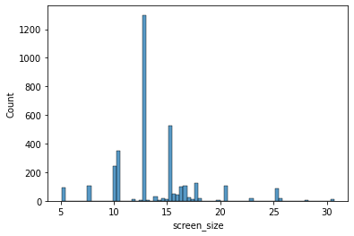

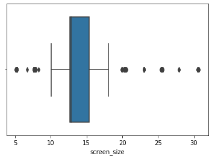

```python
# visualize the distributions of the numerical variables
sns.histplot(data=data, x='screen_size')
plt.show()
sns.boxplot(data=data, x='screen_size')
plt.show()
```

Observation: Most device screens seem to be between ~12-15cm.

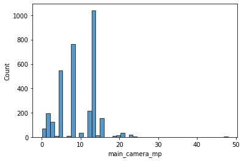

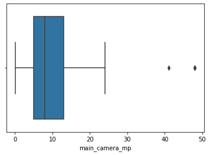

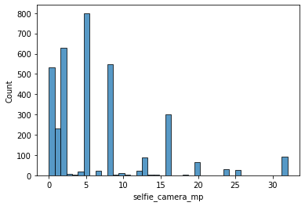

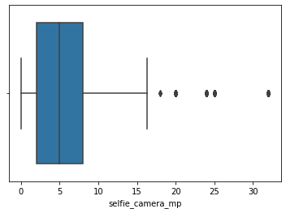

```python
# compare the camera MP distributions
sns.histplot(data=data, x='main_camera_mp')
plt.show()
sns.boxplot(data=data, x='main_camera_mp')
plt.show()

sns.histplot(data=data, x='selfie_camera_mp')
plt.show()
sns.boxplot(data=data, x='selfie_camera_mp')
plt.show()
```

```python
print(data['main_camera_mp'].mean())
print(data['selfie_camera_mp'].mean())
```

```
9.460207633587787
6.554229432213209
```

Observations: Neither of the distributions for camera MP are normal. Selfie cameras tend to have lower MP with the average around 6.55MP versus the average for main cameras being closer to 9.46MP.

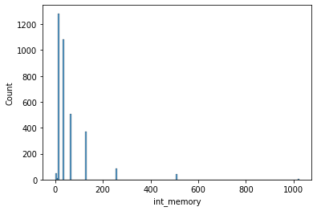

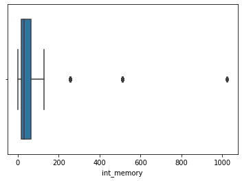

```python
sns.histplot(data=data, x='int_memory')
plt.show()
sns.boxplot(data=data, x='int_memory')
plt.show()
```

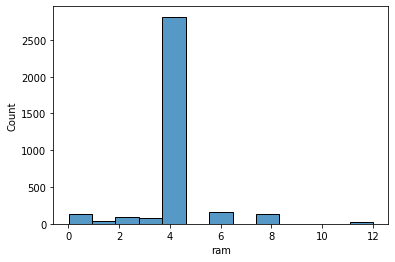

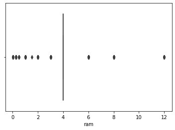

```python
sns.histplot(data=data, x='ram')
plt.show()
sns.boxplot(data=data, x='ram')
plt.show()
```

```python
data['ram'].mode()
```

```
0    4.0
dtype: float64
```

Observation: The majority of devices seem to have a RAM right around 4

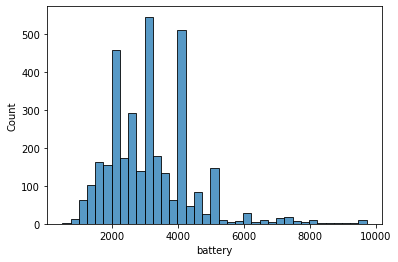

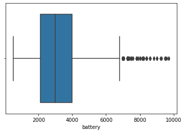

```python
sns.histplot(data=data, x='battery')
plt.show()
sns.boxplot(data=data, x='battery')
plt.show()
```

Observation: ~50% of devices have a battery between 2,000-4,000 mAh, with the median battery being around 3,000 mAh.

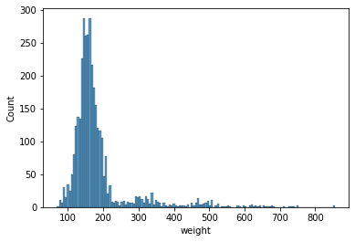

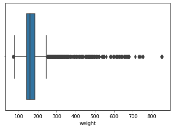

```python
sns.histplot(data=data, x='weight')
plt.show()
sns.boxplot(data=data, x='weight')
plt.show()
```

Observation: Most devices have a weight between 100-200 grams.

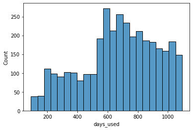

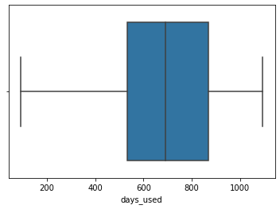

```python
sns.histplot(data=data, x='days_used')
plt.show()
sns.boxplot(data=data, x='days_used')
plt.show()
```

Observation: The vast majority of devices have been used for over a year.

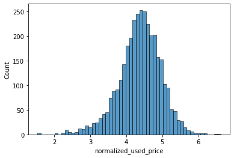

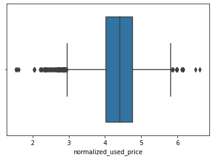

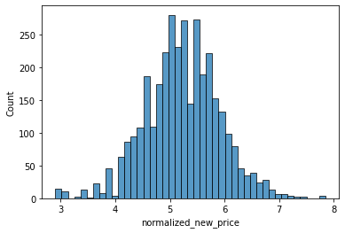

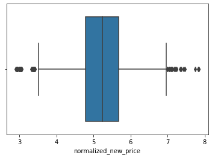

```python
# compare price distributions
sns.histplot(data=data, x='normalized_used_price')
plt.show()
sns.boxplot(data=data, x='normalized_used_price')
plt.show()

sns.histplot(data=data, x='normalized_new_price')
plt.show()
sns.boxplot(data=data, x='normalized_new_price')
plt.show()
```

```python
print(data['normalized_used_price'].mean())
print(data['normalized_new_price'].mean())
```

```
4.364712079133227
5.233107171901414
```

Observation: The average normalized used price of 4.4 is much lower than the average normalized new price of 5.2.

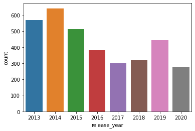

```python
sns.countplot(data=data, x='release_year')
plt.show()
```

Observation: Most devices were released in 2014 and the least amount of used devices were released in 2020.

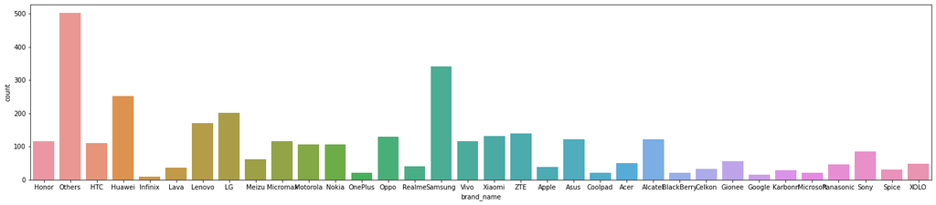

```python
# now let's look at categorical variables
plt.figure(figsize=(25,5))
sns.countplot(data=data, x='brand_name')
plt.show()
```

Observations: Most devices are 'Other' brands, but the single brand with the highest count of devices is Samsung. Infinix seems to have the least.

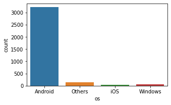

```python
plt.figure(figsize=(5,3))
sns.countplot(data=data, x='os')
plt.show()
```

Observation: Android OS is by far the most popular amongst used devices.

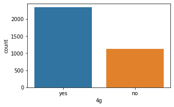

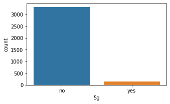

```python
plt.figure(figsize=(5,3))
sns.countplot(data=data, x='4g')
plt.show()

plt.figure(figsize=(5,3))
sns.countplot(data=data, x='5g')
plt.show()
```

Observations: Our initial observation was correct - there are more used devices that are 4g compatible and not many that are 5g compatible.

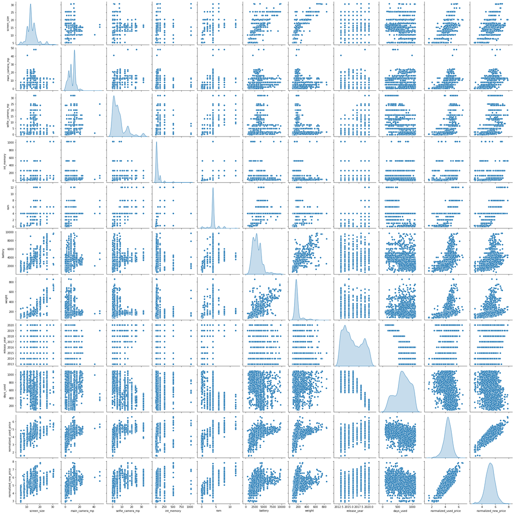

```python
# let's use a pairplot to see the distributions of each variable and if/how variables are correlated
sns.pairplot(data=data, diag_kind="kde")
plt.show()
```

Observations: There seems to be strong, positive correlations between normalized used price & normalized new price. There also seems to be a positive correlation between battery & weight and between weight & screen size.

### 1. What does the distribution of normalized used device prices look like?

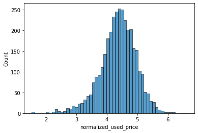

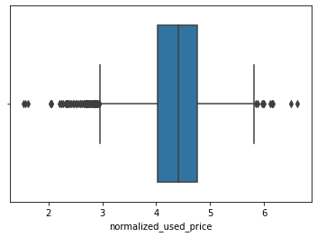

```python
# visualizing with a histogram & boxplot
sns.histplot(data=data, x='normalized_used_price')
plt.show()
sns.boxplot(data=data, x='normalized_used_price')
plt.show()
```

Observation: The majority of normalized used prices fall between 4 and 5, though there seem to be a lot of outliers under 3 and over ~6.

### 2. What percentage of the used device market is dominated by Android devices?

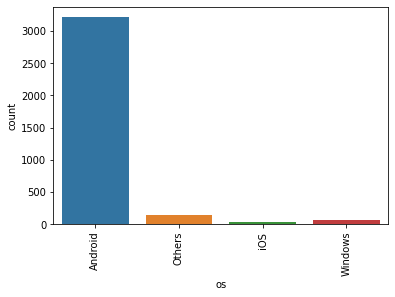

```python
# let's plot the counts by OS
sns.countplot(data=data, x='os')
plt.xticks(rotation=90);
```

```python
# and now let's get the percentage of Android devices
data['os'].value_counts(normalize='true')
```

```
Android    0.930515
Others     0.039664
Windows    0.019398
iOS        0.010423
Name: os, dtype: float64
```

Observation: Android devices make up 93% of the used device market.

### 3. The amount of RAM is important for the smooth functioning of a device. How does the amount of RAM vary with the brand?

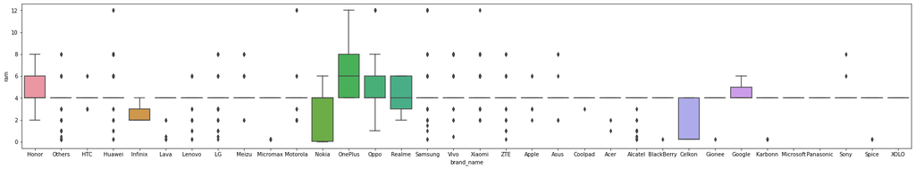

```python
plt.figure(figsize=(30,5))
sns.boxplot(data=data,x='brand_name',y='ram')
plt.show()
```

Observation: The amount of RAM varies largely from brand to brand and even within some brands. For example, ~50% of Honor & Oppo devices seem to have between 4-6GB RAM whereas the majority of Nokia & Celton devices seem to have between 0-4GB RAM. If RAM were the single most important factor in choosing a device, consumers would likely choose OnePlus.

### 4. A large battery often increases a device's weight, making it feel uncomfortable in the hands. How does the weight vary for phones and tablets offering large batteries (more than 4500 mAh)?

```python
# filter large batteries only
large_batts = data[(data['battery']>4500)]
large_batts
```

|  | brand_name | os | screen_size | 4g | 5g | main_camera_mp | selfie_camera_mp | int_memory | ram | battery | weight | release_year | days_used | normalized_used_price | normalized_new_price |
| --- | --- | --- | --- | --- | --- | --- | --- | --- | --- | --- | --- | --- | --- | --- | --- |
| 3 | Honor | Android | 25.50 | yes | yes | 13.0 | 8.0 | 64.0 | 6.0 | 7250.0 | 480.0 | 2020 | 345 | 5.135387 | 5.630961 |
| 4 | Honor | Android | 15.32 | yes | no | 13.0 | 8.0 | 64.0 | 3.0 | 5000.0 | 185.0 | 2020 | 293 | 4.389995 | 4.947837 |
| 11 | Honor | Android | 15.32 | yes | no | 13.0 | 8.0 | 64.0 | 4.0 | 5000.0 | 185.0 | 2020 | 344 | 4.657383 | 4.770176 |
| 19 | Honor | Android | 25.43 | yes | no | 5.0 | 2.0 | 32.0 | 3.0 | 5100.0 | 173.0 | 2019 | 266 | 4.267878 | 5.517051 |
| 20 | Honor | Android | 20.32 | yes | no | 8.0 | 8.0 | 32.0 | 3.0 | 5100.0 | 173.0 | 2019 | 321 | 4.556295 | 5.304001 |
| ... | ... | ... | ... | ... | ... | ... | ... | ... | ... | ... | ... | ... | ... | ... | ... |
| 3420 | Samsung | Android | 15.47 | yes | yes | 8.0 | 13.0 | 128.0 | 12.0 | 5000.0 | 222.0 | 2020 | 197 | 5.623042 | 6.792120 |
| 3421 | Samsung | Android | 15.47 | yes | no | 8.0 | 13.0 | 128.0 | 12.0 | 5000.0 | 220.0 | 2020 | 176 | 5.594265 | 6.960775 |
| 3434 | Samsung | Android | 15.34 | yes | no | 12.0 | 16.0 | 64.0 | 4.0 | 6000.0 | 188.0 | 2019 | 455 | 4.781641 | 5.109937 |
| 3448 | Asus | Android | 16.74 | yes | no | NaN | 24.0 | 128.0 | 8.0 | 6000.0 | 240.0 | 2019 | 325 | 5.715316 | 7.059317 |
| 3449 | Asus | Android | 15.34 | yes | no | NaN | 8.0 | 64.0 | 6.0 | 5000.0 | 190.0 | 2019 | 232 | 4.492337 | 6.483872 |

341 rows × 15 columns

Obervation: There are 341 devices with a battery size over 4,500 mAh.

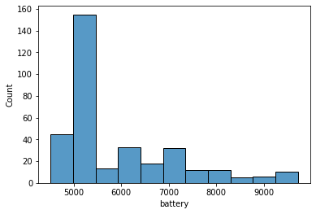

```python
sns.histplot(data=large_batts, x='battery')
plt.show()
```

Observation: Most devices with a battery size over 4,500 mAh actually have a battery size between 5,000-6,000 mAh.

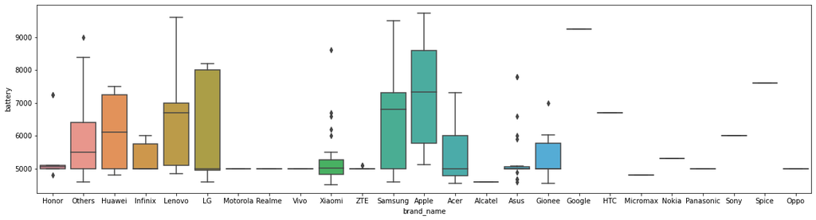

```python
# let's look by brand name
plt.figure(figsize=(20,5))
sns.boxplot(data=large_batts, x='brand_name', y='battery')
plt.show()
```

Observations: There are only 25 brands (including 'others') out of 34 total that have a device with a battery size over 4,500 mAh. Apple is the brand with a device having the highest battery life, which is well above 9,000 mAh.